# MH_Summary_HW

Marilyn Harbert

2024-11-30

## Project Summary

Queer people experience domestic violence differently and thus require different information about domestic violence than straight people. In addition, domestic violence is often framed as a heterosexual women’s issue, leaving queer people out of information provided about domestic violence.

My data for this project is articles discussing domestic violence from the Chicago based LGBTQ+ newspaper “The Windy City”.

# Codebook

I am thinking about how to analyze the topic modeling and bigram generation for this project, and I think I have an initial list of codes I might use to categorize the terms I see in order to make sense of the data. - health : terms related to health - identity : terms related to identity/demographics - violence : terms that reference violence or abuse directly - community : terms related to community or non-profit groups - advocacy : terms related to stopping domestic violence - location : terms that refer to locations

# Data

Link to initial data: https://github.com/marilynharbert/CompText_Jour/blob/main/docs/Summary_HW/ProQuestDocuments-2024-11-17.txt

## Code

### Set options

```r
options(stringsAsFactors = F)         # no automatic data transformation
options("scipen" = 100, "digits" = 4) # suppress math annotation
```

### Extracting data from the .txt file

```r
# Set the path to your .txt file
file_path <- "../Summary_HW/ProQuestDocuments-2024-11-27 (1).txt"

# Read the .txt file line by line
text <- readLines(file_path)

text <- text[-c(1:4)]


# Convert the lines into a dataframe, one line per row
gay_dv_articles <- data.frame(text)
```

### Extract metadata from excel file

```r
metadata <- read_excel("~/Code/CompText_Jour/docs/Summary_HW/ProQuestDocuments-2024-11-27 (1).xls")

# create indices
metadata_dv_windy_city <- metadata %>%
  mutate(index = row_number())
```

### create linked index

```r
# Step 2: Combine lines into one single string
text_combined <- paste(text, collapse = "\n")

# Step 3: Split the text by the "End of Document" phrase
documents <- strsplit(text_combined, "_____________________________________________")[[1]]
### only 213 elements in documents - should be 216

# Step 4: Write each section to a new file
output_dir <- "../Summary_HW/article_data_dv/"
for (i in seq_along(documents)) {
  output_file <- file.path(output_dir, paste0("dv_", i, ".txt"))
  writeLines(documents[[i]], output_file)
}
### i goes up to 213

cat("Files created:", length(documents), "\n")

# says it created 213 files

dv_index <- read_lines("../Summary_HW/article_data_dv/dv_1.txt")
# Extract lines 5 to 215
extracted_lines <- dv_index[3:541]

# Print the extracted lines to the console
# cat(extracted_lines, sep = "\n")

extracted_lines <- extracted_lines |>
  as.data.frame()

# Step 1: Trim spaces and detect rows with titles
cleaned_data <- extracted_lines |>
  mutate(
    # Trim leading and trailing spaces before detection
    trimmed_line = str_trim(extracted_lines),

    # Detect titles (start with a number and a period)
    is_title = str_detect(trimmed_line, "^\\d+\\. "),
  )

metadata_dv_windy_city <- metadata_dv_windy_city %>%
  rename(title = Title)

#new title column with trim numbers from titles

cleaned_data <- cleaned_data %>%
  mutate(title = gsub("^\\d+\\.\\s*", "", trimmed_line)) %>%
  filter(title != "") %>%
  filter(title != " ") %>%
  filter(!is.na(title))

# add indecise
cleaned_data <- cleaned_data %>%
  mutate(index = row_number())

# add dates
aligned_data <- cleaned_data %>%
  left_join(metadata_dv_windy_city, by = "index")

# Step 3: Rename columns for clarity
final_data <- aligned_data |>
  #select columns to keep
  select(-c(extracted_lines, StoreId, companies, copyright, issn, language,
            languageOfSummary, pages, entryDate, DocumentURL, documentFeatures,
            identifierKeywords, startPage, subjectTerms, subjects, FindACopy,
            Database, title.y)) %>%
  #rename to good names
  rename(date = pubdate,
         abstract = Abstract,
         article_type = ArticleType,
         authors = Authors,
         document_type = documentType,
         place_ofpublication = placeOfPublication,
         title = title.x)

write_csv(final_data, "../Summary_HW/dv_index_data.csv")

files <- list.files("../Summary_HW/article_data_dv/", pattern="dv.*.txt") %>%
  as.data.frame() |>
  rename(filename = 1) |>
  #create an index with the file name
  mutate(index = str_extract(filename, "\\d+")) |>
  mutate(index = as.numeric(index))

final_index <- final_data |>
  inner_join(files, c("index")) |>
  mutate(filepath = paste0("../Summary_HW/article_data_dv/", filename))

create_article_text <- function(row_value) {

  #row_value is the single argument that is passed to the function
  # Take each row of the dataframe
  temp <- final_index %>%
    slice(row_value)

  # Store the filename for  use in constructing articles dataframe
  temp_filename <- temp$filename

  # Create a dataframe by reading in lines of a given textfile
  # Add a filename column
  articles_df_temp <- read_lines(temp$filepath) %>%
    as_tibble() %>%
    mutate(filename = temp_filename)

  # Bind results to master articles_df
  # <<- returns to global environment
  articles_df <<- articles_df %>%
    bind_rows(articles_df_temp)
}

# Create empty tibble to store results
articles_df <- tibble()

# Create an array of numbers to loop through, from 1 to the number of rows in our index dataframe
row_values <- 1:nrow(final_index)

lapply(row_values, create_article_text)

articles_df <- articles_df %>%
  select(filename, sentence=value) %>%
  inner_join(final_index)

articles_df <- articles_df %>%
  slice(-c(2:533)) |>
  #gets rid of blank rows
    filter(trimws(sentence) != "")

write.csv(articles_df, "../Summary_HW/dvlinkedindex.csv")
```

### Cleaning: get rid of the junk!

```r
#clean up text column
clean_df <- articles_df %>%
  mutate(text = str_squish(sentence)) %>% #gets rid of leading and trailing spaces + double spaces
  mutate(text = tolower(text)) %>%
  mutate(text = str_replace(text, "startofarticle", "")) %>%
  mutate(text = str_replace_all(text, "__", "")) %>%
  mutate(text = gsub("issn:\\s+\\S+", "", text)) %>%
  mutate(text = gsub("http[^ ]*", "http", text)) %>%
  mutate(text = str_replace_all(text, c(
    "copyright" = "",
    "database: proquest central" = "",
    "language of publication: english" = "",
    "document url:\\s+\\S+" = "",
    "proquest document id:\\s+\\S+" = "",
    "publication subject:\\s+\\S+" = "",
    "publication date:\\s+\\S+" = "",
    "publication-type:\\s+\\S+" = "",
    "pages:\\s+\\S+" = "",
    "publication info" = "",
    "last updated:\\s+\\S+" = "",
    "interest periodicals--united states" = "",
    "all rights resesrved" = "",
    "load-date" = "",
    "all rights reserved" = "",
    "new york times" = "",
    "language: english" = "",
    "author:\\s+\\S+" = "",
    "abstract:\\s+\\S+" = "",
    "links:\\s+\\S+" = "",
    "publication title:\\s+\\S+" = "",
    "volume:\\s+\\S+" = "",
    "issue:\\s+\\S+" = "",
    "publication year:\\s+\\S+" = "",
    "publisher: windy city media group" = "",
    "place of publication: chicago, ill." = "",
    "country of publication: united states, chicago, ill." = "",
    "document type:\\s+\\S+" = "",
    "database: genderwatch" = "",
    "identifier / keyword: y; genderwatch" = "",
    "source type: newspaper" = "",
    "windy city times" = "",
    "umcp.primo.exlibrisgroup.com\\s+\\S+" = "",
    "usmai-umcp.primo.exlibrisgroup.com" = "",
    "id doi" = "",
    "Links: https://usmai-umcp.primo.exlibrisgroup.com/" = "",
    "windy city media group" = "",
    "city times; chicago, ill." = "",
    "http" = "",
    "document feature:\\s+\\S+" = "",
    "feature photographs" = "",
    "full text:" = "",
    "city times" = "",
    "subject:\\s+\\S+" = "",
    "company / organization:\\s+\\S+" = "",
    "location:\\s+\\S+" = "",
    "illinois; united states--us; illinois" = "",
    "business indexing term:" = "",
    "ch icago, ill." = "",
    "title" = "",
    "web site:\\s+\\S+" = ""
  )))

#used Chat GPT to get the regexes in this section
# prompts used:
# # what is the regex for .
# # what is the escape character in regular expressions
# # what R code should I use to remove all strings with "ISSN" and the phrase immediately following that one from a dataset?
# # give me r code to get rid of any characters that come after "http" but before a space in a string
```

### Tokenize the data

```r
#Tokenize the data
bitoken_clean_df <- clean_df %>%
  unnest_tokens(bigram, text, token="ngrams", n=2)

bigrams_separated <- bitoken_clean_df %>%
  separate(bigram, c("word1", "word2"), sep = " ")

#remove stop words and
data(stop_words)
bigrams_separated <- bigrams_separated %>%
  filter(!word1 %in% stop_words$word) %>%
  filter(!word2 %in% stop_words$word) %>%
  filter(word1  != "https") %>%
  filter(word2  != "https") %>%
  filter(!grepl('[0-9]',word1)) %>%
  filter(!grepl('[0-9]',word2))
```

### Descriptive statistics

```r
# number of lines
count_lines <- clean_df %>%
  summarise(count_lines = n())

# number of lines per article
count_lines_index <- clean_df %>%
  group_by(index) %>%
  summarise(count_lines = n())

# number of words per article
count_df <- clean_df %>%
  group_by(index) %>%
  summarise(count_words = str_count(text, '\\S+')) %>%
  summarise(count_lines = sum(count_words))
```

## Top 20 bigrams

```r
bigrams_filtered <- bigrams_separated %>%
  filter(!word1 %in% stop_words$word) %>%
  filter(!word2 %in% stop_words$word)

bigram_ct <- bigrams_filtered %>%
  count(word1, word2, sort = TRUE) %>%
  filter(!is.na(word1))

top_20_bigrams <- head(bigram_ct, 20)
```

```r
formattable(top_20_bigrams,
            align =c("c","c","c","c","c", "c", "c", "c", "r"),
            list(
              `Top 20 Bigrams` = formatter(
              "span", style = ~ style(color = "black",font.weight = "bold")),
              `n`= color_tile("cadetblue1", "dodgerblue2")

))
```

| word1 | word2 | n |
| --- | --- | --- |
| domestic | violence | 438 |
| cook | county | 210 |
| lgbt | community | 166 |
| illinois | united | 113 |
| hiv | aids | 110 |
| sexual | orientation | 107 |
| openly | gay | 104 |
| anti | violence | 100 |
| intimate | partner | 97 |
| executive | director | 95 |
| partner | violence | 90 |
| gays | lesbians | 88 |
| lgbtq | community | 86 |
| african | american | 82 |
| marriage | equality | 81 |
| gender | identity | 75 |
| circuit | court | 74 |
| amigas | latinas | 65 |
| lgbt | people | 65 |
| human | rights | 60 |

## Plot Top 20 Bigrams

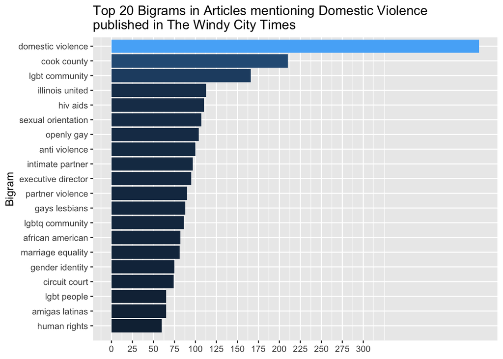

```r
bigram_ct_toplot <- head(bigram_ct,20) %>%
  mutate(bigram = paste0(word1, " ", word2)) %>%
  mutate(n = as.numeric(n))

bi_plot <- ggplot(data=bigram_ct_toplot, aes(fill = n, x = reorder(bigram, n), y = n)) +
  geom_col() +
  scale_y_continuous(breaks = seq(0, 300, by = 25)) +
  labs(y = NULL,
       x = "Bigram") +
  coord_flip() +
  ggtitle("Top 20 Bigrams in Articles mentioning Domestic Violence\npublished in The Windy City Times") +
  theme(legend.position="none") +
  expand_limits(x = 0, y = 0)

plot(bi_plot)
```

## map years

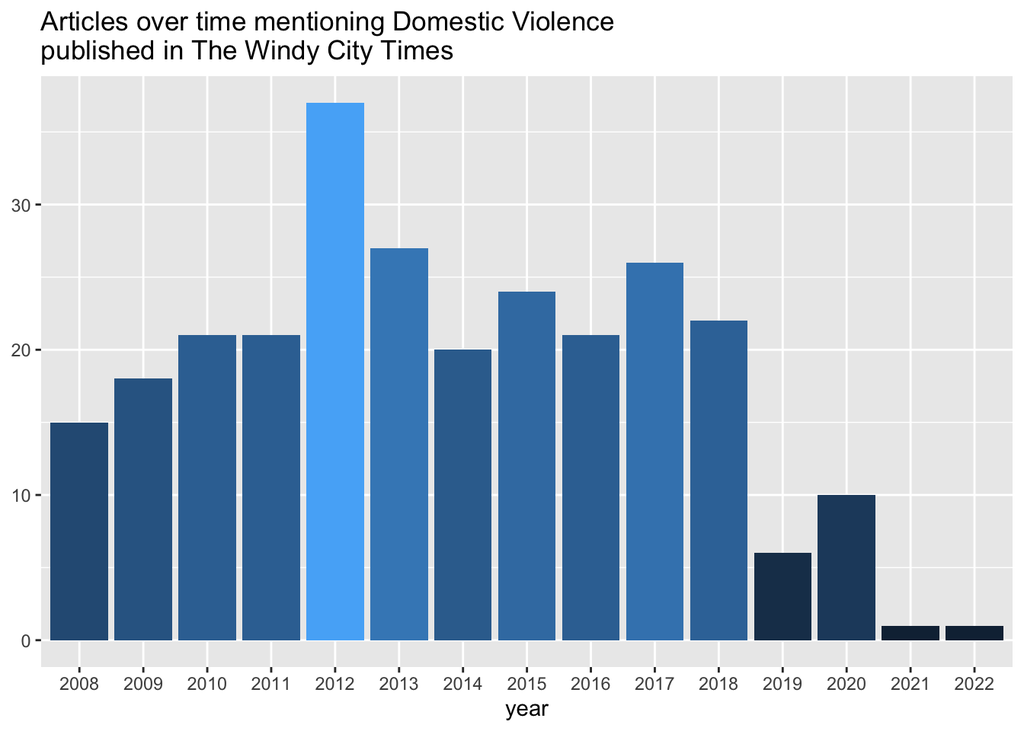

```r
year_df <- clean_df %>%
  select(year, index) %>%
  distinct() %>%
  count(year)

year_plot <- ggplot(data=year_df, aes(year, n, fill = n)) +
  geom_col() +
  labs(y = NULL,
       x = "year") +
  ggtitle("Articles over time mentioning Domestic Violence\npublished in The Windy City Times") +
  theme(legend.position="none")

plot(year_plot)
```

# topic modeling

```r
# create new dataframe from cleaned data to have just the text
textdata <- clean_df %>%
  select(filename, text, year) %>%
  as.data.frame() %>%
  rename(doc_id = filename, text= text)

# load stopwords
english_stopwords <- readLines("https://slcladal.github.io/resources/stopwords_en.txt", encoding = "UTF-8")
# create corpus object
corpus <- Corpus(DataframeSource(textdata))
# Preprocessing chain
processedCorpus <- tm_map(corpus, content_transformer(tolower))
processedCorpus <- tm_map(processedCorpus, removeWords, english_stopwords)
processedCorpus <- tm_map(processedCorpus, removePunctuation, preserve_intra_word_dashes = TRUE)
processedCorpus <- tm_map(processedCorpus, removeNumbers)
processedCorpus <- tm_map(processedCorpus, stemDocument, language = "en")
processedCorpus <- tm_map(processedCorpus, stripWhitespace)
```

```r
#DTM: rows correspond to the documents in the corpus. Columns correspond to the terms in the documents. Cells correspond to the weights of the terms. (Girder)
# compute document term matrix with terms >= minimumFrequency
minimumFrequency <- 5
DTM <- DocumentTermMatrix(processedCorpus, control = list(bounds = list(global = c(minimumFrequency, Inf))))
# have a look at the number of documents and terms in the matrix
dim(DTM)
# due to vocabulary pruning, we have empty rows in our DTM
# LDA does not like this. So we remove those docs from the
# DTM and the metadata
sel_idx <- slam::row_sums(DTM) > 0
DTM <- DTM[sel_idx, ]
textdata <- textdata[sel_idx, ]
```

We examine topics in the data over time by aggregating mean topic proportions per year These aggregated topic proportions can then be visualized, e.g. as a bar plot.

## Articles per year

```r
articles_years <- textdata %>%
  distinct(doc_id, .keep_all=TRUE) %>%
  count(year) %>%
  mutate(pct_total= (n/sum(n))) %>%
  mutate(pct_total= formattable::percent(pct_total)) %>%
  mutate(pct_total = round(pct_total, 1)) %>%
  arrange(desc(year))

library(kableExtra)
articles_years %>%
  kbl(caption = "DV Windy City Times Articles by Year (n=270, 11/27/2024)", font_size = 30) %>%
  kable_classic(full_width = F, html_font = "Cambria") %>%
  column_spec(1, bold = T, border_right = T) %>%
  column_spec(2, width = "5em") %>%
  column_spec(3, width = "5em", background = "yellow")
```

[output not shown]

```r
# number of topics
# K <- 20
K <- 6
# set random number generator seed
set.seed(9161)
#Latent Dirichlet Allocation, LDA
topicModel2 <- LDA(DTM, K, method="Gibbs", control=list(iter = 500, verbose = 25, alpha = 0.2))
tmResult <- posterior(topicModel2)
theta <- tmResult$topics
beta <- tmResult$terms
topicNames <- apply(terms(topicModel2, 10), 2, paste, collapse = " ")  # reset topicNames
```

### Mean topic proportions per yaer

```r
# Step 1: Check dimensions
n_theta <- nrow(theta)
n_textdata <- length(textdata$year)

cat("Number of rows in theta: ", n_theta, "\n")
cat("Number of documents in textdata: ", n_textdata, "\n")

# Check if textdata contains all the documents in theta
common_ids <- intersect(rownames(theta), textdata$doc_id) # Assuming textdata has a 'doc_id' column

# Filter textdata to include only the documents present in theta
textdata_filtered <- textdata[textdata$doc_id %in% common_ids, ]

# Check dimensions after filtering
n_textdata_filtered <- nrow(textdata_filtered)
cat("Number of documents in filtered textdata: ", n_textdata_filtered, "\n")

# Ensure the lengths match now
if (n_theta != n_textdata_filtered) {
  stop("The number of rows in 'theta' still does not match the length of 'textdata_filtered$year'.")
}

# Align rownames of theta with filtered textdata
theta_aligned <- theta[rownames(theta) %in% textdata_filtered$doc_id, ]

# Optional: Verify the order of documents
if (!all(rownames(theta_aligned) == textdata_filtered$doc_id)) {
  # If the order doesn't match, reorder one to match the other
  textdata_filtered <- textdata_filtered[match(rownames(theta_aligned), textdata_filtered$doc_id), ]
}

# Ensure they are now aligned and can be combined
if (!all(rownames(theta_aligned) == textdata_filtered$doc_id)) {
  stop("The document IDs still do not match. Please check the data alignment.")
}

# Step 2: Combine data
topic_data <- data.frame(theta_aligned, year = textdata_filtered$year)

# Step 3: Aggregate data
topic_proportion_per_year <- aggregate(. ~ year, data = topic_data, FUN = mean)

# get mean topic proportions per decade
# topic_proportion_per_decade <- aggregate(theta, by = list(decade = textdata$decade), mean)
# set topic names to aggregated columns
colnames(topic_proportion_per_year)[2:(K+1)] <- topicNames
# reshape data frame
vizDataFrame <- melt(topic_proportion_per_year, id.vars = "year")
```

### Examine topic names

```r
#enframe(): Converts a named list into a dataframe.
topics <- enframe(topicNames, name = "number", value = "text") %>%
  unnest(cols = c(text))

topics <- topics %>%
  kbl() %>%
  kable_styling()

topics
```

| number | text |
| --- | --- |
| Topic 1 | chicago work communiti organ lgbt center servic health univers youth |
| Topic 2 | chicago show perform music gay theatr center event featur halst |
| Topic 3 | state illinoi counti gay unit race marriag cook elect district |
| Topic 4 | violenc peopl women domest communiti sexual black queer abus report |
| Topic 5 | number law polic offic case peopl year report hiv charg |
| Topic 6 | peopl time year work famili life make love wct thing |

### Review the topics and determine a 1-2 word label after reading the source documents.

```r
theta2 <- as.data.frame(theta)

topic1 <- theta2 %>%
  rownames_to_column(var = "file") |> # putting the rownames into a new column called file
  mutate(file = str_remove(file, "^X"),  # Remove leading 'X'
         line = str_extract(file, "(?<=\\.txt)\\.\\d+")) |>   # Extract number after .txt
  mutate(file = str_remove(file, "\\.\\d+$")) |>
  rename(topic1 = '1') |>
  top_n(20, topic1) |>
  arrange(desc(topic1)) |>
  select(file, line, topic1)
```

### add categories

```r
#add categories
vizDataFrame <- vizDataFrame %>%
  mutate(category = case_when(
    str_detect(variable,  "chicago work communiti organ lgbt center servic health univers youth") ~ "community_org",
    str_detect(variable, "chicago show perform music gay theatr center event featur halst") ~ "theater",
    str_detect(variable, "state illinoi counti gay unit race marriag cook elect district") ~ "elect",
    str_detect(variable, "violenc peopl women domest communiti sexual black queer abus report") ~ "domestic_abuse",
     str_detect(variable, "number law polic offic case peopl year report hiv charg") ~ "legal",
    str_detect(variable, "peopl time year work famili life make love wct thing") ~ "life",
    ))
```

# Fact Check and Validate Topics

1 - chicago work communiti organ lgbt center servic health univers youth

2 - chicago show perform music gay theatr center event featur halst

3 - state illinoi counti gay unit race marriag cook elect district

4 - violenc peopl women domest communiti sexual black queer abus report

5 - number law polic offic case peopl year report hiv charg

6 - peopl time year work famili life make love wct thing

### for community_org

```r
theta2 <- as.data.frame(theta)

community_org <- theta2 %>%
  #renaming for a general topic
  rename(community_org = '1') %>%
  top_n(20, community_org) %>%
  arrange(desc(community_org)) %>%
  select(community_org)

# Apply rownames_to_column
community_org  <- tibble::rownames_to_column(community_org, "story_id")

community_org$story_id <- gsub("X", "", community_org$story_id)
```

### for legal

```r
legal <- theta2 %>%
  #renaming for a general topic
  rename(legal = '5') %>%
  top_n(20, legal ) %>%
  arrange(desc(legal )) %>%
  select(legal )

# Apply rownames_to_column
legal  <- tibble::rownames_to_column(legal , "story_id")

legal $story_id <- gsub("X", "", legal $story_id)
```

### for domestic_abuse

```r
domestic_abuse <- theta2 %>%
  #renaming for a general topic
  rename(domestic_abuse = '4') %>%
  top_n(20, domestic_abuse ) %>%
  arrange(desc(domestic_abuse )) %>%
  select(domestic_abuse )

# Apply rownames_to_column
domestic_abuse  <- tibble::rownames_to_column(domestic_abuse , "story_id")

domestic_abuse $story_id <- gsub("X", "", domestic_abuse $story_id)
```

### Figure 3: Common Narratives in Windy City Times articles mentioning domestic violence

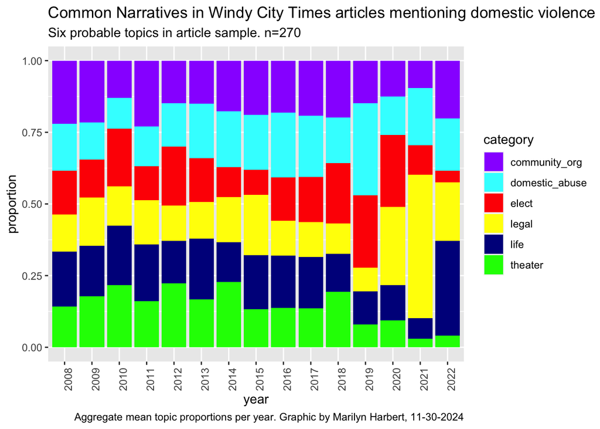

```r
# plot topic proportions per decade as bar plot
ggplot(vizDataFrame, aes(x=year, y=value, fill=category)) +
  geom_bar(stat = "identity") + ylab("proportion") +
  scale_fill_manual(values = paste0(alphabet(20), "FF"), name = "year") +
  theme(axis.text.x = element_text(angle = 90, hjust = 1)) +
   scale_fill_manual(values=c("#9933FF",
                              "#33FFFF",
                              "red",
                              "yellow",
                              "darkblue",
                              "green"))+
  labs(title = "Common Narratives in Windy City Times articles mentioning domestic violence",
       subtitle = "Six probable topics in article sample. n=270",
       caption = "Aggregate mean topic proportions per year. Graphic by Marilyn Harbert, 11-30-2024")
```

# Sentiment Analysis

```r
get_sentiments("afinn")

load("../Summary_HW/data/afinn.rda")
```

```r
nrc_articles <- get_sentiments("nrc")

tidy_articles <- clean_df %>%
  unnest_tokens(word, text)

tidy_articles %>%
  inner_join(nrc_articles) %>%
  count(word, sort = TRUE)
```

```r
bing_articles <- tidy_articles %>%
  inner_join(get_sentiments("bing")) %>%
  count(index, sentiment) %>%
  pivot_wider(names_from = sentiment, values_from = n, values_fill = 0) %>%
  mutate(sentiment = positive - negative)
```

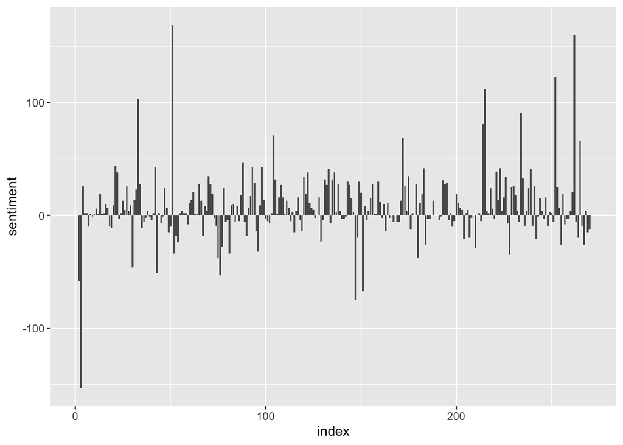

```r
ggplot(bing_articles, aes(index, sentiment)) +
  geom_col(show.legend = FALSE)
```

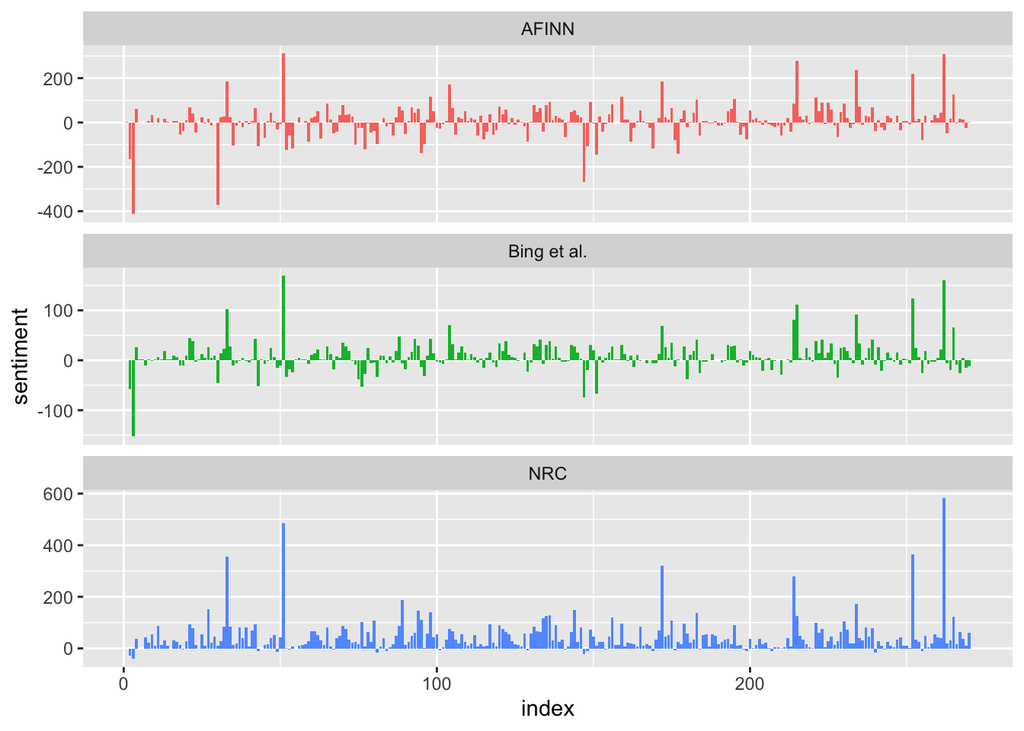

```r
afinn <- tidy_articles %>%
  inner_join(get_sentiments("afinn")) %>%
  group_by(index) %>%
  summarise(sentiment = sum(value)) %>%
  mutate(method = "AFINN")

bing_and_nrc <- bind_rows(
  tidy_articles %>%
    inner_join(get_sentiments("bing")) %>%
    mutate(method = "Bing et al."),
  tidy_articles %>%
    inner_join(get_sentiments("nrc") %>%
                 filter(sentiment %in% c("positive",
                                         "negative"))) %>%
    mutate(method = "NRC")) %>%
  count(method, index, sentiment) %>%
  pivot_wider(names_from = sentiment,
              values_from = n,
              values_fill = 0) %>%
  mutate(sentiment = positive - negative)


bind_rows(afinn, bing_and_nrc) %>%
  ggplot(aes(index, sentiment, fill = method)) +
  geom_col(show.legend = FALSE) +
  facet_wrap(~method, ncol = 1, scales = "free_y")
```

```r
bing_word_counts <- tidy_articles %>%
  inner_join(get_sentiments("bing")) %>%
  count(word, sentiment, sort = TRUE) %>%
  ungroup()

bng_cnts <- head(bing_word_counts, 20) %>%
  kbl() %>%
  kable_styling()

bng_cnts
```

| word | sentiment | n |
| --- | --- | --- |
| work | positive | 624 |
| like | positive | 494 |
| queer | negative | 347 |
| issues | negative | 314 |
| well | positive | 303 |
| support | positive | 293 |
| abuse | negative | 209 |
| love | positive | 169 |
| right | positive | 169 |
| skinny | negative | 161 |
| worked | positive | 153 |
| good | positive | 144 |
| important | positive | 138 |
| openly | positive | 138 |
| discrimination | negative | 134 |
| better | positive | 128 |
| available | positive | 125 |
| free | positive | 123 |
| issue | negative | 123 |
| intimate | positive | 117 |

## Words left out of sentiment analysis

```r
left_out <- tidy_articles %>%
  anti_join(get_sentiments("bing")) %>%
  filter(!word %in% stop_words$word) %>%
  count(word, sort = TRUE) %>%
  ungroup()

lft_out <- head(left_out, 20) %>%
  kbl() %>%
  kable_styling()

lft_out
```

| word | n |
| --- | --- |
| chicago | 1592 |
| people | 1416 |
| violence | 1158 |
| community | 947 |
| gay | 865 |
| women | 767 |
| illinois | 752 |
| lgbt | 751 |
| domestic | 551 |
| center | 500 |
| time | 489 |
| hiv | 479 |
| lgbtq | 443 |
| aids | 388 |
| health | 375 |
| black | 352 |
| law | 348 |
| gender | 343 |
| lesbian | 339 |
| youth | 334 |